# Introduction to practical disease modeling: Exercise 2

Exercises with infection dynamics

# 1. Introducing herd dynamics

We use the same herd model as introduced earlier. This time we simulate a disease, that infects the cows at random. The disease is chronic, meaning that all susceptible cows can be infected, and will stay there. Thus, it is an *SI* model.

```r
set.seed(250)

n_cows <- 100

# Create the farm:
farm <- data.frame(id =1:n_cows,
                   age=round(runif(n_cows,730,1642)),
                   infected=0)

# We start by initially infected one cow - the first one:
farm$infected[1] <- 1

# We set the probability of infection:
ProbInfection <- 0.01

# We want to simulate 5 years:
end_time <- 5 * 365

# Collect the mean age of the cows in herd over time:
age_collect <- numeric(end_time)

# Collect the number of susceptible and infected animals at each time point:
inf_collect <- data.frame(susceptible=rep(0,end_time), infected=rep(0, end_time))

for (t in seq_len(end_time))
{

    # Identify the cows that are not infected (susceptible):
    PotInf       <- which(farm$infected==0)
    # Draw randomly which of the cows that should be (newly) infected:
    NewInf       <- PotInf[rbinom(length(PotInf),1,prob=ProbInfection)==1]
    # If there are new infections, then we infect them:
    if(length(NewInf)>0) farm$infected[NewInf] <- 1

   # Add one day to the age of all the animals, for each simulated:
   farm$age <- farm$age + 1

   # Save the daily mean age of all cows:
   age_collect[t] <- mean(farm$age)

   # Save the number of susceptible and infected:
   sus <- length(farm$infected[farm$infected==0])
   inf <- length(farm$infected[farm$infected==1])
   inf_collect[t,1] <- sus
   inf_collect[t,2] <- inf
}
```

And we plot the course of infection dynamics:

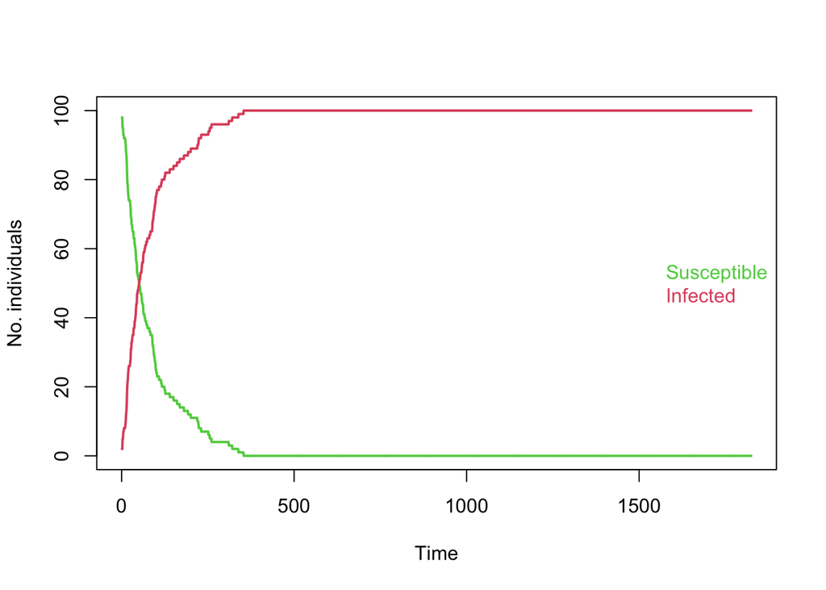

```r
plot(inf_collect$susceptible, type="l", lwd=2, col=3, xlab="Time", ylab="No. individuals", ylim=c(0,n_cows))
lines(inf_collect$infected, type="l", lwd=2, col=2)
legend("right", text.col=c(3,2), legend=c("Susceptible", "Infected"),
       bty="n")
```

The number of susceptible individuals decrease over time and the number of infected individuals increase.

# 2. Exercises

Hint: Modify the above code to solve the exercises.

## A.

ProbInf is the equivalent of the beta parameter commonly used in simulation models. It is the probability that a new infection will occur.

Try to adjust the ProbInf up and down. Can you make the number of susceptible and infected cross each other right in the middle of the simulation? How does the stochastic element come into play here?

### Solution

It is difficult to control the stochastic process. However, parameters can be tweaked so they on average cross each other in the middle of the simulation.

## B.

Try to make the probability of infection dependent on the number of infected individuals, for example like: Beta * Number of infected / total number of individuals.

### Solution

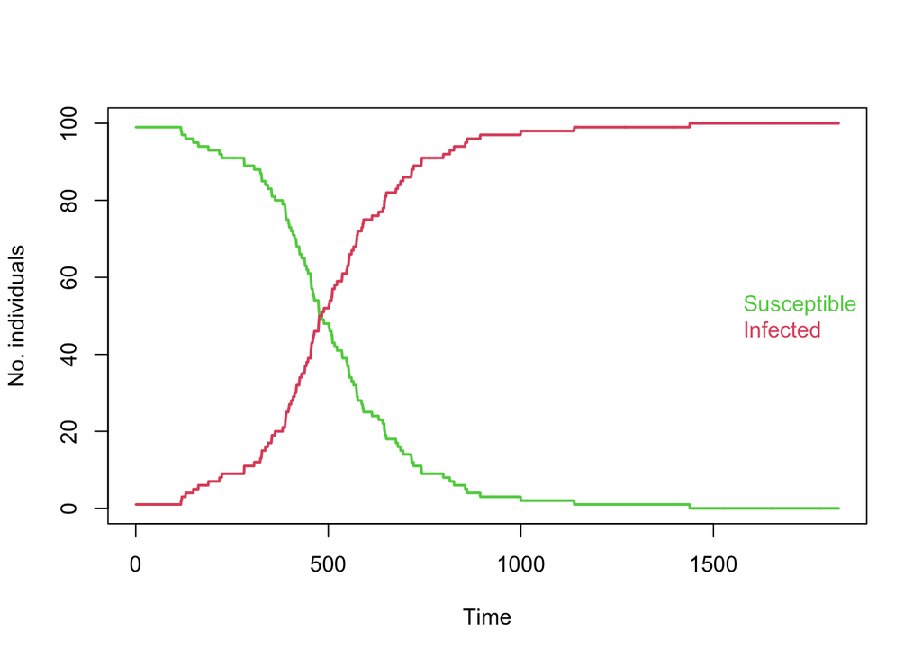

```r
set.seed(250)

n_cows <- 100

# Create the farm:
farm <- data.frame(id =1:n_cows,
                   age=round(runif(n_cows,730,1642)),
                   infected=0)

# We start by initially infected one cow - the first one:
farm$infected[1] <- 1

# We set the probability of infection:
Beta <- 0.01

# We want to simulate 5 years:
end_time <- 5 * 365

# Collect the mean age of the cows in herd over time:
age_collect <- numeric(end_time)

# Collect the number of susceptible and infected animals at each time point:
inf_collect <- data.frame(susceptible=rep(0,end_time), infected=rep(0, end_time))

for (t in seq_len(end_time))
{
    # We update the ProbInf within the model:
    ProbInfection <- Beta * sum(farm$infected==1) / n_cows

    # Identify the cows that are not infected (susceptible):
    PotInf       <- which(farm$infected==0)
    # Draw randomly which of the cows that should be (newly) infected:
    NewInf       <- PotInf[rbinom(length(PotInf),1,prob=ProbInfection)==1]
    # If there are new infections, then we infect them:
    if(length(NewInf)>0) farm$infected[NewInf] <- 1

   # Add one day to the age of all the animals, for each simulated:
   farm$age <- farm$age + 1

   # Save the daily mean age of all cows:
   age_collect[t] <- mean(farm$age)

   # Save the number of susceptible and infected:
   sus <- length(farm$infected[farm$infected==0])
   inf <- length(farm$infected[farm$infected==1])
   inf_collect[t,1] <- sus
   inf_collect[t,2] <- inf
}


plot(inf_collect$susceptible, type="l", lwd=2, col=3, xlab="Time", ylab="No. individuals", ylim=c(0,n_cows))
lines(inf_collect$infected, type="l", lwd=2, col=2)
legend("right", text.col=c(3,2), legend=c("Susceptible", "Infected"),
       bty="n")
```

## C.

Modify the model so that there is a third compartment, Recovered (R) that infected individuals can enter with a certain probability.

### Solution

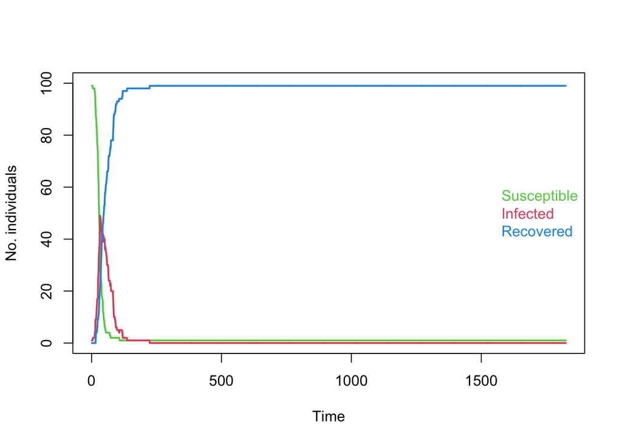

```r
set.seed(250)

n_cows <- 100

# Create the farm:
farm <- data.frame(id =1:n_cows,
                   age=round(runif(n_cows,730,1642)),
                   infected=0)

# We now have three compartments in the "infected" column:
# 0 = Susceptible
# 1 = Infected
# 2 = Recovered

# We start by initially infected one cow - the first one:
farm$infected[1] <- 1

# We set the probability of infection:
Beta <- 0.19

# We set the probability of cure:
Gamma <- 0.03

# We want to simulate 5 years:
end_time <- 5 * 365

# Collect the mean age of the cows in herd over time:
age_collect <- numeric(end_time)

# Collect the number of susceptible and infected animals at each time point:
inf_collect <- data.frame(susceptible=rep(0,end_time), infected=rep(0, end_time), recovered=rep(0, end_time))

for (t in seq_len(end_time))
{
   # We update the ProbInf within the model:
   ProbInfection <- Beta * sum(farm$infected==1) / n_cows

   ### Infection ###

   # Identify the cows that are not infected (susceptible):
   PotInf       <- which(farm$infected==0)
   # Draw randomly which of the cows that should be (newly) infected:
   NewInf       <- PotInf[rbinom(length(PotInf),1,prob=ProbInfection)==1]
   # If there are new infections, then we infect them:
   if(length(NewInf)>0) farm$infected[NewInf] <- 1

   ### Recovery ###

   # Identify the cows that are infected:
   PotRec       <- which(farm$infected==1)
   # Draw randomly which of the cows that should recover:
   NewRec       <- PotRec[rbinom(length(PotRec),1,prob=Gamma)==1]
   # If there are any recoveries, they recover:
   if(length(NewRec)>0) farm$infected[NewRec] <- 2

   # Add one day to the age of all the animals, for each simulated:
   farm$age <- farm$age + 1

   # Save the daily mean age of all cows:
   age_collect[t] <- mean(farm$age)

   # Save the number of susceptible, infected and recovered:
   sus <- length(farm$infected[farm$infected==0])
   inf <- length(farm$infected[farm$infected==1])
   rec <- length(farm$infected[farm$infected==2])

   inf_collect[t,1] <- sus
   inf_collect[t,2] <- inf
   inf_collect[t,3] <- rec
}


plot(inf_collect$susceptible, type="l", lwd=2, col=3, xlab="Time", ylab="No. individuals", ylim=c(0,n_cows))
lines(inf_collect$infected, type="l", lwd=2, col=2)
lines(inf_collect$recovered, type="l", lwd=2, col=4)
legend("right", text.col=c(3,2, 4), legend=c("Susceptible", "Infected", "Recovered"),
       bty="n")
```

## D.

A more realistic scenario is that the individuals recover after a fixed number of days, for example 10 days. Try to include that in the model. Hint: You will need to set a counter to keep track of how many days the infected individuals have before they can recover. Plot the output.

### Solution

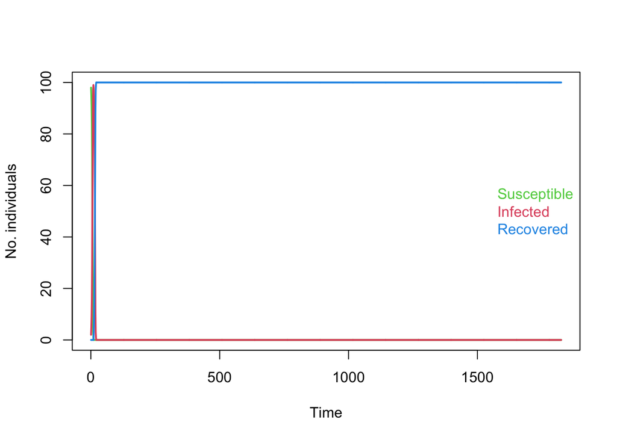

```r
set.seed(5)

n_cows <- 100

# Create the farm:
farm <- data.frame(id =1:n_cows,
                   age=round(runif(n_cows,730,1642)),
                   infected=0, infected_days=0)

# We now have three compartments in the "infected" column:
# 0 = Susceptible
# 1 = Infected
# 2 = Recovered

# We start by initially infected one cow - the first one:
farm$infected[1] <- 1

# We set the probability of infection:
Beta <- 0.85

# We set the length of the infectious period:
infectious_period <- 10

# We want to simulate 5 years:
end_time <- 5 * 365

# Collect the mean age of the cows in herd over time:
age_collect <- numeric(end_time)

# Collect the number of susceptible and infected animals at each time point:
inf_collect <- data.frame(susceptible=rep(0,end_time), infected=rep(0, end_time), recovered=rep(0, end_time))

for (t in seq_len(end_time))
{
   # We update the ProbInf within the model:
   ProbInfection <- Beta * sum(farm$infected==1) / n_cows

   ### Infection ###

   # Identify the cows that are not infected (susceptible):
   PotInf       <- which(farm$infected==0)
   # Draw randomly which of the cows that should be (newly) infected:
   NewInf       <- PotInf[rbinom(length(PotInf),1,prob=ProbInfection)==1]
   # If there are new infections, then we infect them:
   if(length(NewInf)>0) farm$infected[NewInf] <- 1

   # Identify the cows that have been infected for 10 days:
   Rec          <- which(farm$infected_days==infectious_period)
   # If there are any recoveries, they recover:
   if(length(Rec)>0) farm$infected[Rec] <- 2
   # And we set their infected counter to zero again:
   if(length(Rec)>0) farm$infected_days[Rec] <- 0

   # And update the infected days counter (at each time step):
   farm$infected_days[farm$infected==1] <- farm$infected_days[farm$infected==1] + 1


   ### Recovery ###

   # Add one day to the age of all the animals, for each simulated:
   farm$age <- farm$age + 1

   # Save the daily mean age of all cows:
   age_collect[t] <- mean(farm$age)

   # Save the number of susceptible, infected and recovered:
   sus <- length(farm$infected[farm$infected==0])
   inf <- length(farm$infected[farm$infected==1])
   rec <- length(farm$infected[farm$infected==2])

   inf_collect[t,1] <- sus
   inf_collect[t,2] <- inf
   inf_collect[t,3] <- rec
}


plot(inf_collect$susceptible, type="l", lwd=2, col=3, xlab="Time", ylab="No. individuals", ylim=c(0,n_cows))
lines(inf_collect$infected, type="l", lwd=2, col=2)
lines(inf_collect$recovered, type="l", lwd=2, col=4)
legend("right", text.col=c(3,2, 4), legend=c("Susceptible", "Infected", "Recovered"),
       bty="n")
```

# 3. Bonus exercise

Modify the R6 model (bonus exercise from exercise 1) to include these infection dynamics. Include the Beta and Gamma parameters as arguments to the initialize method. Create a new method for infecting an animal, and another method for extracting the current total number of susceptible, infected and recovered animals.

You can also consider encapsulation of independent elements within the class itself i.e. separation of code to update the ages (and implement replacements) from code to update the disease statuses. Try to do this by having private methods called update_ages() and update_disease() where this code is separated, and then calling private$update_ages() and private$update_disease() from within the public update() method. What is the benefit of using encapsulation like this?

### Solution

We can simply extend the model we created for the previous session, although with a few added features to handle encapsulation of code to update age from code to update disease:

```r
library("R6")

## Define the farm class:
Farm <- R6Class("Farm",

  # Private objects that we can only see within the class:
  private = list(

    # The number of cows:
    n_cows = 0L,

    # The age of replacement heifers:
    age_heifer = 0L,

    # The age at which animals are replaced:
    age_replacement = 0L,

    # Beta:
    beta = 0.0,

    # Number of infected days:
    max_infected_days = 0L,

    # The data frame of cows:
    cows = data.frame(id = numeric(0),
                      age = numeric(0),
                      infected = numeric(0),
                      infected_days = numeric(0)),

    # The current time:
    time = 0L,

    # A private method to update age:
    update_age = function() {

          # If cows reach the age of age_replacement, they are replaced with a new cow that is age_heifer days old:
      private$cows$age[private$cows$age>=private$age_replacement] <- private$age_heifer

          private$cows$age <- private$cows$age + 1L

    },

    # A private method to update disease:
    update_disease = function() {

      ## Work out which animals move between compartments:

          # Update prob_inf partly using a method we define below:
          ProbInfection <- private$beta * self$get_totals()["infected"] / private$n_cows

      # Identify the cows that are not infected (susceptible):
      PotInf <- which(private$cows$infected==0)
      # Draw randomly which of the cows that should be (newly) infected:
      NewInf <- PotInf[rbinom(length(PotInf),1,prob=ProbInfection)==1]

      # Identify the cows that have been infected for 10 days so will recover:
      Rec <- which(private$cows$infected_days >= private$max_infected_days)


          ## Then move animals between compartments

      # If there are new infections, then we infect them:
      if(length(NewInf)>0){
        private$cows$infected[NewInf] <- 1
        private$cows$infected_days[NewInf] <- 0
      }

      # If there are any recoveries, they recover and we set their infected counter to zero again:
      if(length(Rec)>0) {
        private$cows$infected[Rec] <- 2
        private$cows$infected_days[Rec] <- 0
      }

          ## Then update the infected days counter:
      private$cows$infected_days[private$cows$infected==1] <- private$cows$infected_days[private$cows$infected==1] + 1

    }

  ),

  # The public methods:
    public = list(

      # An initialize method is mandatory:
        initialize = function(n_cows, age_heifer = 730, age_replacement = 1642, beta = 0.01, infected_days=10L) {

          # Set the number of cows:
          private$n_cows <- n_cows

          # Store the ages using the public method we provide below:
          self$set_replacement_ages(age_heifer = age_heifer, age_replacement = age_replacement)

          # Store beta:
          self$set_beta(beta)

          # Store infected_days:
          self$set_infected_days(infected_days)

          # Set the data frame of cows:
          private$cows <- data.frame(id = 1:n_cows,
                          age = round(runif(n_cows,age_heifer,age_replacement)),
                      infected = 0,
                      infected_days = 0)

          # Set the time:
          private$time <- 1L

        },

        # A set method for the replacement ages:
        set_replacement_ages = function(age_heifer = NULL, age_replacement = NULL) {
          if(!is.null(age_heifer)) private$age_heifer <- age_heifer
          if(!is.null(age_replacement)) private$age_replacement <- age_replacement
        },

        # A set method for beta:
        set_beta = function(beta) {
          private$beta <- beta
        },

        # A set method for infected_days:
        set_infected_days = function(infected_days) {
          private$max_infected_days <- infected_days
        },

        # An infect method to change the status of a single cow:
        infect = function(cow) {

          private$cows$infected[cow] <- 1L
          private$cows$infected_days[cow] <- 0L

        },

        # An update method for a single time step:
        update = function() {

          ## First some sanity checks to help find bugs:
          stopifnot(all(private$cows$infected %in% c(0,1,2)))
          stopifnot(all(private$cows$infected_days >= 0))

          ## Then update disease:
          private$update_disease()

          ## Then update ages:
          private$update_age()

          ## Then increment the time:
      private$time <- private$time + 1L

        },

        # A method to get the current cows:
        get_cows = function() {

          return(private$cows)

        },

        # A method to get the current average age:
        get_mean_age = function() {

          mean_age <- mean(private$cows$age)
          return(mean_age)

        },

        # A method to get the number of susceptible, infected and recovered:
        get_totals = function() {

          stopifnot(all(private$cows$infected %in% c(0,1,2)))
          rv <- c(
            susceptible = sum(private$cows$infected==0L),
            infected = sum(private$cows$infected==1L),
            recovered = sum(private$cows$infected==2L)
          )

          return(rv)

        }

    )
)
```

Separating out the update_age() and update_disease() methods has two benefits:

1. We end up with smaller chunks of code that each do a specific thing. This makes it easier to work out what each aspect of the model does - particularly if e.g. we are only interested with the disease part of the model and not the age part of the model.
2. It makes it easier to add complexity to specific parts of the model without having to worry about potential side effects on the rest of the code. We also open up the ability to test specific parts of the class independently when we modify them, for example if we know that we have only modified the age part of the model then we only need to test this part of the overall update method.

The only potential disadvantage is that a user of this class (e.g. your future self) may not know (or have forgotten) that the update_age() and update_disease() modules must both be run for the model to make sense. We avoid the danger of running only 1 of them by making the two separate parts private methods so that they cannot accidentally be run in “production code”, and then maintaining a single overall update() method which calls the individual specific parts of the model. This is extremely good programming practice, and your future self will thank you for doing this!

Note that the code to run this is very similar to before, except we now need to initialise infection and also capture the total susceptible/infected/recovered at each time step:

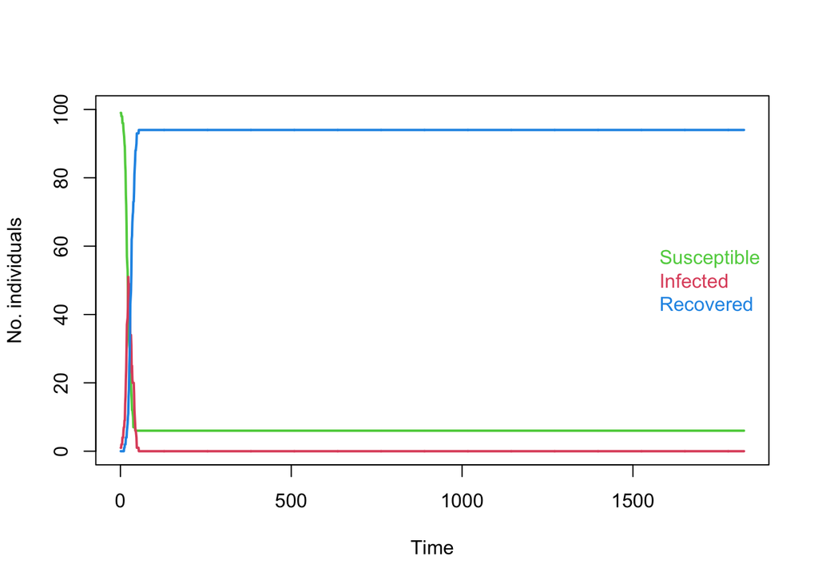

```r
# Create a new object, specifying beta explicitly so that it is more interesting:
farm <- Farm$new(n_cows = 100L, beta = 0.25)

end_time <- 5 * 365
age_collect <- numeric(end_time)
inf_collect <- data.frame(susceptible=rep(0,end_time), infected=rep(0, end_time), recovered=rep(0, end_time))

# First we must initialise infection in animal 1:
farm$infect(1L)

# Then we can loop over the other time points:
for (t in seq_len(end_time)) {

   # Update the object:
   farm$update()

   # Save the daily mean age of all cows:
   age_collect[t] <- farm$get_mean_age()

   # Save the infection statuses:
   inf_collect[t,1:3] <- farm$get_totals()
}

plot(inf_collect$susceptible, type="l", lwd=2, col=3, xlab="Time", ylab="No. individuals", ylim=c(0,n_cows))
lines(inf_collect$infected, type="l", lwd=2, col=2)
lines(inf_collect$recovered, type="l", lwd=2, col=4)
legend("right", text.col=c(3,2, 4),
       legend=c("Susceptible", "Infected", "Recovered"), bty="n")
```

In particular, we do not see from this “top level” code that the age and disease steps are actually separated - this is an “implementation-level detail” that we do not need to worry about when actually using the model. This separation of “what a class can be used for” from “exactly how the class does what it does” is a key feature of object-oriented programming.